# MINICURSO: ANÁLISE DE DADOS COM R

Materiais utilizados no minicurso “Análise de dados com R”, ministrado por Luisa Gisele Böck, e promovido pelo GPEA em parceria com o PPGE&D da UFSM.

## Materiais

- [Slides](https://lgiselebock.github.io/minicurso-r/)
- [Scripts](https://github.com/lgiselebock/minicurso-r/tree/master/scripts)
- [Dados](https://github.com/lgiselebock/minicurso-r/tree/master/dados)

Para fazer o download, clique sobre a base desejada e depois no botão `Dowload raw file`.

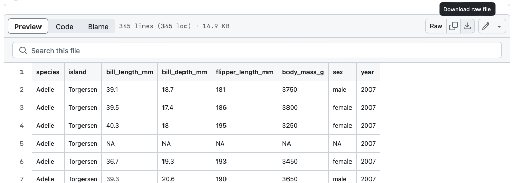

Exemplo de como realizar o Download

## Materiais extras

### Livros

- [Avaliação econômica de projetos sociais](https://www.itausocial.org.br/wp-content/uploads/2018/05/avaliacao-economica-3a-ed_1513188151.pdf) - Naercio Aquino Menezes Filho e Cristine Campos de Xavier Pinto (orgs.)
- [Avaliação de Impacto na Prática](https://openknowledge.worldbank.org/bitstream/handle/10986/25030/9781464808890.pdf) - Banco Mundial
- [Causal Inference: The Mixtape](https://mixtape.scunning.com/index.html) - Scott Cunningham
- [Guia Brasileiro de Análise de Dados](https://repositorio.enap.gov.br/bitstream/1/6039/1/Guia%20BR%20de%20Ana%cc%81lise%20de%20Dados.pdf) - Claudio D. Shikida, Leonardo Monasterio e Pedro Fernando Nery (eds.)
- Linear Regression Models Applications in R - John P. Hoffmann
- Mastering Metrics: The Path from Cause to Effect - Joshua D. Angrist and Jörn-Steffen Pischke
- Mostly Harmless Econometrics - Joshua D. Angrist and Jörn-Steffen Pischke
- [The Efect: An Introduction to Research Design and Causality](https://theeffectbook.net/) - Nick Huntington-Klein
- Using R for Introductory Econometris - Florian Heiss

### Artigos

- [How to do Empirical Economics](https://www.redalyc.org/pdf/173/17330202.pdf) - Kramarz (editor)
- [Linear Regression: A Visual Introduction To (Almost) Everything You Should Know](https://mlu-explain.github.io/linear-regression/) - Jared Wilber

### Vídeos

- Playlist [Econometria](https://www.youtube.com/playlist?list=PLxafIQjs0M97dPDvvFdsD4I6yn4qj_2ja) - Estudar com Você
- Playlist [Econometrics](https://www.youtube.com/playlist?list=PLcTBLulJV_ALLS7R_e7ig0aEcBrtp6B18) - Nick Huntington-Klein
- Playlist [Causality](https://www.youtube.com/playlist?list=PLcTBLulJV_AKmUTH-nUsxxFyRQoWnUzxU) - Nick Huntington-Klein
- Playlist [R for Economists](https://www.youtube.com/playlist?list=PLcTBLulJV_AIuXCxr__V8XAzWZosMQIfW) - Nick Huntington-Klein
- Playlist [Orientação de Pesquisa](https://www.youtube.com/playlist?list=PL5zwgb1bvX2Jz4CZUTgaeAAIF5FoMV_3F) - Thomas Conti
- Playlist [Mastering Econometrics with Joshua Angrist](https://www.youtube.com/playlist?list=PL-uRhZ_p-BM5ovNRg-G6hDib27OCvcyW8) - Marginal Revolution University

### Materiais para aprender a Linguagem R

- [A very short introduction to Tidyverse](https://dominicroye.github.io/en/2020/a-very-short-introduction-to-tidyverse/) - Dominic Royé
- [An Introduction to Statistical Learning: with Applications in R](https://hastie.su.domains/ISLRv2_website.pdf) - Gareth James, Daniela Witten, Trevor Hastie and Robert Tibshirani
- [Ciência de dados econômicos](https://tidyeconomics.netlify.app/) - Felipe O. Gonçalves
- [Cookbook for R](http://www.cookbook-r.com/) - Paul Teetor
- [Livro Curso-R](https://livro.curso-r.com/) - Curso-R
- [R for Data Science](https://r4ds.had.co.nz/) - Hadley Wickham and Garrett Grolemund
- [R: Uma Introdução para economistas](https://danmrc.github.io/R-para-Economistas/) - Daniel Coutinho

Uma das vantagens de se utilizar o **R** é a existência de pacotes criados para trabalhar diretamente com os dados brasileiros. Por exemplo:

- Pacotes para dados financeiros: [Importando e Manipulando Dados Financeiros no R](http://wilsonfreitas.github.io/slides/ser-maio-2018/index.html#1) - Wilson Freitas
- PNAD Contínua: [Análise de microdados da PNAD Contínua](https://rpubs.com/BragaDouglas/335574) - Douglas Braga
- Pacote [Brazilian Economic Time Series (BETS)](https://github.com/nmecsys/BETS) - Pedro Costa Ferreira, Talitha Speranza e Jonatha Costa
- Pacote deflateBR: - Fernando Meirelles
- Pacote [electionsBR](http://electionsbr.com/): dados eleitorais brasileiros - Denisson Silva, Fernando Meireles e Beatriz Costa
- Pacote [geobr](https://cran.r-project.org/web/packages/geobr/vignettes/intro_to_geobr.html): mapas e outros dados espaciais brasileiros - Rafael H. M. Pereira e Caio Nogueira Goncalves
- Um [exemplo](http://regisely.com/blog/mercado-de-trabalho-covid/) do uso dos dados da PNAD Covid - Régis Ely

Base dos Dados Mais (BD+): um repositório integrado de dados organizados e disponíveis na nuvem dentro da ferramenta BigQuery, da Google. Com algumas linhas de código, bases de dados que levariam dias para baixar e tratar podem ser acessadas dentro de alguns minutos. - João Carabetta, Ricardo Dahis, Fred Israel e Fernanda Scovino

- As bases disponíveis podem ser vistas neste [link](https://basedosdados.org/dataset/?download_type=BD+Mais)
- Neste [vídeo](https://www.youtube.com/watch?v=5_Ir8neyFf4&t=626s) mostra-se como utilizar a BD+ no R.
- Há também um pacote no R (posterior ao vídeo) para acessar as bases de dados. Tutoriais podem ser encontrados neste [artigo](https://dev.to/basedosdados/como-usar-a-biblioteca-basedosdados-no-r-capitulo-1-46kb) e neste [vídeo](https://www.youtube.com/watch?v=M9ayiseIjvI&t=5s).

### Materiais para aprender a Linguagem Python

Além do **R**, o **Python** também é utilizado para a análise de dados. Aqui estão alguns materiais caso vocês tenham interesse em aprender outra linguagem de programação:

- [Introduction to Python for Econometrics, Statistics and Data Analysis](https://bashtage.github.io/kevinsheppard.com/files/teaching/python/notes/python_introduction_2020.pdf) - Kevin Sheppard
- [Learn Python](https://www.learnpython.org/)
- [Mini Curso de Python](https://estatsite.com.br/mini-curso-de-python-gratuito/) - Estatsite
- Using Python for Introductory Econometris - Florian Heiss and Daniel Brunner

### Visualização de dados

- [An Economist’s Guide to Visualizing Data](https://pubs.aeaweb.org/doi/pdf/10.1257/jep.28.1.209) - Jonathan A. Schwabish
- [Extensões do ggplot2](https://exts.ggplot2.tidyverse.org/gallery/)
- [Fundamentals of Data Visualization](https://clauswilke.com/dataviz/) - Claus O. Wilke
- [The pie chart](https://dominicroye.github.io/en/2018/the-pie-chart/) - Dominic Royé